# Aplicaciones del Aprendizaje Estadístico a la segmentación del mercado turístico

Llorenç B. Femenias

21/11/2019

# 1. Introducción y justificación

El turismo representa el 12.3% del PIB y el 12.7% del empleo total en España (INE, Cuenta satélite del turismo de España, 2019), siendo uno de los sectores claves en la economía del país. Como es de esperar en una industria con semejante relevancia, el uso de técnicas de aprendizaje estadístico, automático o minería de datos para mejorar la toma de decisiones en las empresas del sector está a la orden del día.

Algunos ejemplos de estas aplicaciones están relacionadas con el análisis de la demanda turística (Law, Mok, & Goh, 2007), la aplicación de los análisis de Big Data para la generación de conocimiento de destinaciones turísticas (Fuchs, Höpken, & Lexhagen, 2014), la clasificación de “sentimientos” en las “reviews” de las destinaciones turísticas (Ye, Zhang, & Law, 2009), entre muchos otros casos.

Entre estos campos de aplicación destaca el de la segmentación de mercado. La segmentación de mercado (por motivación, por actividades a realizar, por presupuesto disponible, …) constituye una herramienta fundamental a la hora de gestionar destinaciones y empresas (p.e: establecimientos hoteleros) turísticas, principalmente por el impacto que tiene en términos de márqueting (Dolnicar, 2008; Tkaczynski, Rundle-Thiele, & Beaumont, 2009).

Para este trabajo, se realizará un análisis de la segmentación, a partir de la motivación del viaje (p.e: turismo de sol y playa, turismo cultural, …), del mercado turístico interno en España mediante la aplicación de un gran número de técnicas de aprendizaje supervisado, con el fin de encontrar aquellos modelos que obtengan unos mejores niveles de predicción. El análisis se llevará a cabo mediante el software estadístico R.

# 2. Data Wrangling

```r
df <- read_csv("~/Documents/Segmentacion-mercado-turistico/Dataset/data_turismo.csv")

# Solo año 2017
df %>% filter( anyo == 2017) -> df

# Codificación de variables categóricas
df$provdest <- as.factor(df$provdest)
df$transprin <- as.factor(df$transprin)
df$ccaa_residencia <- as.factor(df$ccaa_residencia)
df$motiv <- as.factor(df$motiv)
```

La base de datos utilizada en este proyecto proviene de los microdatos de la Encuesta de Turismo Residente publicada mensualmente por el INE desde 2015 (INE, 2019). Esta base de datos recopila información sobre una muestra representativa de familias españolas en viajes turísticos, entendiendo los viajes turísticos como todos aquellos viajes a un destino fuera del entorno habitual de residencia de la persona, que involucra al menos una pernoctación fuera del entorno mencionado y que tienen una duración inferior a un año.

Entre las variables incluidas en la base de datos (un total de 121) encontramos información sobre las regiones de origen y destino de cada viaje, el motivo del viaje (sol y playa, cultural, deportivo,…), el medio de transporte utilizado (coche, avión,…), el tipo de alojamiento en destino (hotel, apartamento, casa familiar,…), entre muchas otras variables.

También encontramos información sociodemográfica de los turistas como: edad, nivel educativo, o los ingresos familiares de. La base de datos contiene un total de 243,447 obseraciones desde 2015. En 2017, el último año con datos no provisionales, la encuesta recopiló información sobre 67,953 viajes.

Con el objetivo de perder el menor número de observaciones posibles, se descartan todas aquellas variables que tengan más de un 10% de observaciones faltantes (NA’s).

```r
# Descartar aquellas columnas con más de un 10% de NA's
df <- df[, -which(colMeans(is.na(df)) > 0.1)]
```

Siguiendo una voluntad de replicabilidad en el ámbito no-académico, se han eliminado todas aquellas variables que contienen información “ex post” o que resultan irrelevantes para el estudio (p.e: identificadores). Por tanto, la selección final de variables tan solo incluye aquellas que pueden obtenerse de forma previa mediante el uso de “cookies” (p.e: provincia de origen) o la contestación a un cuestionario/formulario (p.e: actividades que le gustaría realizar, con quien tiene pensado viajar, etc.).

También se han eliminado todas aquellas observaciones que presentan valores faltantes o NA’s

```r
# Eliminamos variables que no son de interes o están repetidas
df <- df[,-c(100)] # columna sobrante
df$paisdest <- NULL # no variación
df$destesp <- NULL # no variación
df$id <- NULL
df$anyo <- NULL
df$idsec <- NULL
df$bloque_etapas <- NULL
df$npernoc <- NULL
df$paquete <- NULL
df$impu_parcial <- NULL
df$gastofi_paq <- NULL
df$gasto_trans <- NULL
df$gasto_barest <- NULL
df$gasto_act <- NULL
df$gasto_aloja <- NULL
df$gasto_biendur <- NULL
df$gasto_resto <- NULL
df$igastofi_paq <- NULL
df$igastofi_act <- NULL
df$igastofi_aloja <- NULL
df$igastofi_barest <- NULL
df$igastofi_biendur <- NULL
df$igastofi_resto <- NULL
df$igastofi_total <- NULL
df$igastofi_trans <- NULL
df$factorgas_tot <- NULL
df$factorvi_15mas <- NULL
df$factorvi_tot <- NULL
df$miemv_15menos <- NULL
df$dest_costa <- NULL
df$dest_pen <- NULL
df$orden_rep <- NULL
df$orden_viaje <- NULL
df$ccaadest <- NULL
df$paisdest <- NULL
df$destesp <- NULL
df$gasto_paq <- NULL
df$gastofi_act <- NULL
df$gastofi_aloja <- NULL
df$gastofi_barest <- NULL
df$gastofi_biendur <- NULL
df$gastofi_resto <- NULL
df$gastofi_trans <- NULL
df$corr15_vt <- NULL
df$transprin <- NULL

# Eliminar NA's
df <- na.omit(df)

# Dataframe numerico
df.numeric <- data.matrix(df)
df.numeric <- na.omit(df.numeric)
```

La variable dependiente de nuestro análisis es la de “motivo de viaje”. En la siguiente tabla se presentan las 18 categorías que puede tomar dicha variable.

```r
levels(df$motiv)
```

```
##  [1] "Centro trabajo"                 "Compras"
##  [3] "Congresos"                      "Cultural"
##  [5] "Desplazamiento estudio/trabajo" "Educacion"
##  [7] "Gastronomic"                    "Incentivos"
##  [9] "Nature"                         "Otro ocio"
## [11] "Personal_Otros"                 "Religioso"
## [13] "Reuniones"                      "Salud"
## [15] "Spa"                            "Sports"
## [17] "Sun and beach"                  "Visita familiar"
```

En el caso de realizar un estudio puramente teórico, se podrían utilizar todas las categorías incluidas en la encuesta. Sin embargo, debido a la naturaleza de este trabajo, no se han considerado todos aquellos viajes realizados por motivos cuya naturaleza no se puede atribuir exclusivamente a la voluntad del turista (p.e: identificar previamente a un turista cuya motivación es la de visitar a un familiar puede tener poco valor para una empresa que ofrezca servicios turísticos a la hora de realizar, por ejemplo, acciones de marketing on-line).

Finalmente, se han considerado las 8 categorías expuestas en la siguiente tabla, dónde también se expone el peso relativo de cada una de ellas sobre el total de las observaciones consideradas.

```r
df %>%
        filter(motiv != "Visita familiar") %>%
        filter(motiv != "Personal_Otros") %>%
        filter(motiv != "Centro trabajo") %>%
        filter(motiv != "Incentivos") %>%
        filter(motiv != "Salud") %>%
        filter(motiv != "Congresos") %>%
        filter(motiv != "Educacion") %>%
        filter(motiv != "Religioso") %>%
        filter(motiv != "Reuniones") -> df

df %>%
        group_by(motiv) %>%
        summarise(no_rows = (length(motiv)/nrow(df))*100)
```

```
## # A tibble: 8 x 2
##   motiv         no_rows
##   <fct>           <dbl>
## 1 Compras         0.523
## 2 Cultural       10.2
## 3 Gastronomic     1.07
## 4 Nature          7.69
## 5 Otro ocio      57.0
## 6 Spa             1.06
## 7 Sports          3.43
## 8 Sun and beach  19.0
```

```r
df$motiv <- factor(df$motiv)
df$alojaprin <- factor(df$alojaprin)
```

# 3. Conjunto de entrenamiento y conjunto de prueba

En último lugar, se ha realizado una división del dataset con el objetivo de obtener un conjunto de entrenamiento (que se utilizará para entrenar los diferentes modelos) que contenga el 80% de las observaciones y un conjunto de prueba (con el que se evaluará el rendimiento de cada modelo) con el 20% de las observaciones no incluidas en el conjunto de entrenamiento. Este tipo de división se puede considerar estándar en la aplicación de técnicas de Aprendizaje Estadístico, tal y como señalan manuales de referencias como James, Witten, Hastie, & Tibshirani (2013).

```r
set.seed(111)
library(caTools)
split = sample.split(df$motiv, SplitRatio = 0.8)
df.train = subset(df, split == TRUE)
df.test = subset(df, split == FALSE)
```

Finalmente, es importante señalar que para realizar esta división se ha utilizado la función split.sample del paquete `caTools`. Tal y como se señala en la documentación del paquete, dicha función: “divide los datos del vector Y en dos conjuntos en una relación predefinida mientras conserva las relaciones relativas de diferentes etiquetas en Y. Se utiliza para dividir los datos utilizados durante la clasificación en subconjuntos de entrenamiento y prueba.” (caTools, 2019).

# 4. Aplicación de técnicas de Machine Learning

## 4.1 Métricas para la evaluación de modelos y “tuning”

· Debido a la naturaleza clasificatoria del problema analizado, se ha seleccionado el porcentaje de observaciones correctamente clasificadas como métrica para la evaluación y comparación de los distintos modelos de aprendizaje estadístico implementados.

· Finalmente, con el objetivo de realizar un buen “tuning” de los parámetros de cada uno de los modelos y evitar situaciones de sobreajuste, se utilizará el método de la Validación Cruzada con 5 o 10 “folds”.

## 4.2 Técnicas de Aprendizaje no-Supervisado

A pesar de que el objetivo principal del presente trabajo es la aplicación de técnicas de aprendizaje supervisado, también se aplicará un modelo de Análisis de Componentes Principales (en adelante, PCA).

Al contar con un total de 57 variables, la aplicación de ciertos modelos de aprendizaje supervisado, como el KNN, puede implicar problemas relacionados con la “maldición de dimensión”.

```r
set.seed(111)
pr.out = prcomp(df.numeric, scale=TRUE)
pr.var=pr.out$sdev^2
pve=pr.var/sum(pr.var)
```

Como se puede comprobar, cada uno de los componentes explica un porcentaje pequeño de la varianza total. En concreto, el componente 1, el que más información contiene, tan solo explica el 8.4% de la varianza total.

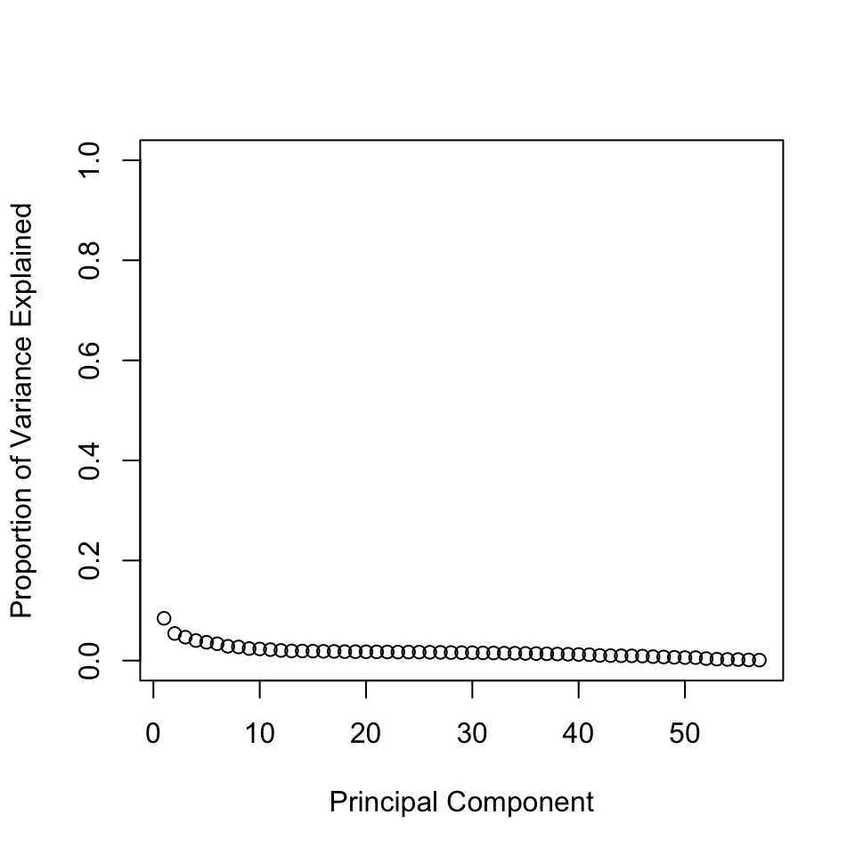

```r
plot(pve, xlab="Principal Component", ylab="Proportion of Variance Explained", ylim=c(0,1),type='b')
```

En el segundo gráfico se ha representado el porcentaje acumulado de la varianza explicada por cada componente. A modo de ejemplo, los primeros 34 componentes principales explican el 80% de la varianza total.

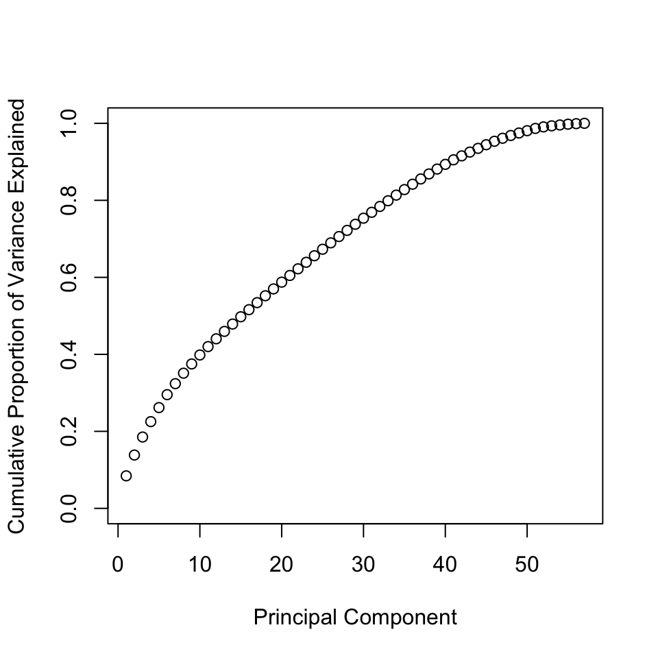

```r
plot(cumsum(pve), xlab="Principal Component", ylab="Cumulative Proportion of Variance Explained", ylim=c(0,1),type='b')
```

Del análisis de este modelo se extrae que existe una baja correlación entre las variables incluidas en el modelo y, por tanto, la reducción del número de variables (dimensiones) podría conllevar una perdida considerable de información.

## 4.3 Técnicas de Aprendizaje Supervisado

### 4.3.a Método de los vecinos más cercanos (KNN)

El método de “vecinos mas cercanos” (en adelante KNN) resulta el modelo de clasificación básico y más intuitivo de entre todos los que se van a aplicar en este trabajo. Cada observación se clasifica en una categoría dependiendo de que categoría es la “dominante” entre sus K vecinos más cercanos.

```r
set.seed(111)
cv10 <- trainControl(method  = "cv", number  = 10)
knn.cv10 <- train(motiv ~ .,
             method     = "knn",
             tuneGrid   = expand.grid(k = 1:10),
             trControl  = cv10,
             metric     = "Accuracy",
             data       = df.train)
knn.cv10
```

```
## k-Nearest Neighbors
##
## 24641 samples
##    56 predictor
##     8 classes: 'Compras', 'Cultural', 'Gastronomic', 'Nature', 'Otro ocio', 'Spa', 'Sports', 'Sun and beach'
##
## No pre-processing
## Resampling: Cross-Validated (10 fold)
## Summary of sample sizes: 22176, 22176, 22176, 22179, 22175, 22178, ...
## Resampling results across tuning parameters:
##
##   k   Accuracy   Kappa
##    1  0.5879219  0.3342276
##    2  0.5658856  0.2986459
##    3  0.5744088  0.2967507
##    4  0.5771690  0.2855519
##    5  0.5823641  0.2832389
##    6  0.5831337  0.2762697
##    7  0.5847164  0.2715434
##    8  0.5848384  0.2649062
##    9  0.5848795  0.2589838
##   10  0.5817963  0.2461886
##
## Accuracy was used to select the optimal model using the largest value.
## The final value used for the model was k = 1.
```

Como se puede comprobar en la tabla anterior, el mejor modelo se obtiene con K = 1, es decir, clasificando cada observación a partir de la categoría de su vecino más cercano.

```r
set.seed(111)
ind <- sample(2, nrow(df.numeric), replace=TRUE, prob=c(0.8, 0.2))
df.train.num <- df.numeric[ind==1, -c(3), drop = TRUE]
df.test.num <- df.numeric[ind==2, -c(3), drop = TRUE]
trainlabes <- df.numeric[ind==1, 3, drop = TRUE]
testlabels <- df.numeric[ind==2, 3, drop = TRUE]

knn.pred.1 <- knn(train = df.train.num, test = df.test.num, cl = trainlabes, k=1)

knn.accuracy.k1 = mean(knn.pred.1==testlabels)
```

Una vez seleccionado K = 1 se aplica el mismo modelo a los datos del conjunto de prueba, obteniéndose un porcentaje de observaciones correctamente clasificadas igual a 0.62.

Si lo comparamos el clasificador mas “ingenuo” posible (clasificar todas las observaciones como la categoría con mayor representación en la muestra), con el método de KNN con K=1 se obtiene una mejora de 4.56 puntos percentuales. Por tanto, este modelo supone una mejora desde el punto de partida.

### 4.3.b Regresión Logística

```r
set.seed(111)
glm.fit.cv10 <- multinom(motiv ~., data = df.train, MaxNWts = 100000, K = 10, maxit = 1000)
glm.preds.cv10 = predict(glm.fit.cv10, type="class", newdata = df.test)
logit.accuracy = mean(glm.preds.cv10==df.test$motiv)
```

Aplicando el modelo Logit con Validación Cruzada, tras 450 iteraciones, se ha obtenido un porcentaje de observaciones correctamente clasificadas igual a 0.71. Esto supone un incremento de 10 puntos porcentuales sobre el clasificador KNN.

### 4.3.c Análisis Discriminante Lineal (LDA)

El tercer modelo aplicado es el Análisis Discriminante Lineal (LDA) que, según la teoría, actúa mejor que el modelo Logístico cuando los datos están bien separado en clases y cuando se trabajan con más de dos clases.

```r
lda.fit <- train(motiv ~ . -provdest,
             method     = "lda",
             trControl  = cv10,
             metric     = "Accuracy",
             data       = df.train)
lda.pred = predict(lda.fit, newdata = df.test)
table(lda.pred, df.test$motiv)
```

```
##
## lda.pred        Compras Cultural Gastronomic Nature Otro ocio  Spa Sports
##   Compras             9        5           2      2        27    0      3
##   Cultural            2      335           0     38       200    2      5
##   Gastronomic         1       70          63     25       128    0      5
##   Nature              0       37           0    183       144    0     22
##   Otro ocio          17      118           0    177      2443    6     61
##   Spa                 0       10           1     13        45   54      6
##   Sports              0        5           0     12        57    0    101
##   Sun and beach       3       51           0     24       469    3      8
##
## lda.pred        Sun and beach
##   Compras                   6
##   Cultural                 16
##   Gastronomic              38
##   Nature                   10
##   Otro ocio               131
##   Spa                      24
##   Sports                    4
##   Sun and beach           939
```

```r
lda.accuracy = mean(lda.pred == df.test$motiv)
```

### 4.3.d Árbol de decisión

En las siguientes secciones se van a explorar métodos relacionados con los árboles de decisión. En este primer apartado se ha estimado un Árbol de Decisión simple con los datos del conjunto de entrenamiento.

```r
set.seed(111)
tree.tourism = tree(motiv~. -provdest, data = df.train)
summary(tree.tourism)
```

```
##
## Classification tree:
## tree(formula = motiv ~ . - provdest, data = df.train)
## Variables actually used in tree construction:
## [1] "acti_playa"        "alojaprin"         "acti_visitascultu"
## [4] "acti_sender"
## Number of terminal nodes:  8
## Residual mean deviance:  1.821 = 44850 / 24630
## Misclassification error rate: 0.3291 = 8109 / 24641
```

Como se puede observar, el árbol llega a una profundidad de 4 niveles. Las actividades de playa son el factor más importante en la determinación de la clase de turista. En caso de que un turista manifieste su voluntad de realizar dicho tipo de actividad (acti_playa =1) en la destinación, dependiendo el tipo de alojamiento que elija, será catalogado como turista de “Sol y playa” o turista de “Otro Ocio” (alojamientos de las categorías 8, 10, 12 y 13).

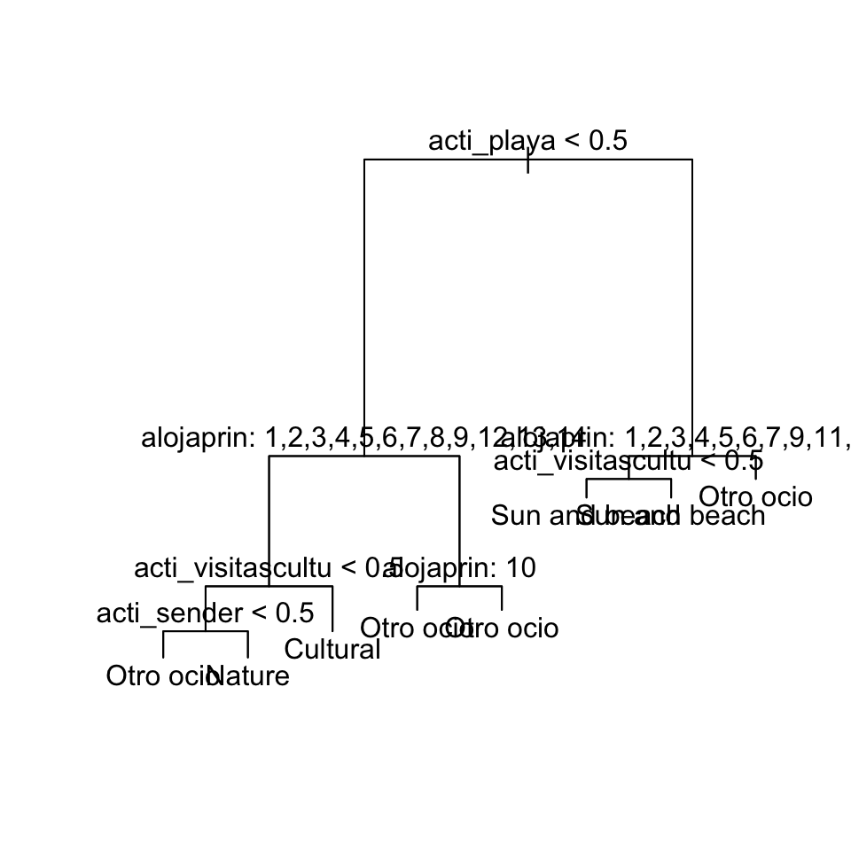

```r
plot(tree.tourism); text(tree.tourism, pretty = 0)
```

A partir del diagrama anterior se observa con claridad que las únicas variables que considera el modelo como relevantes para la categorización de la motivación de los turistas son: practicar actividades de playa, visitas culturales, senderismo y el tipo de alojamiento preferido por el turista.

```r
tree.pred = predict(tree.tourism, df.test, type = "class")
tree.accuracy = mean(tree.pred==df.test$motiv)
```

Cuando aplicamos los datos del conjunto de prueba, obtenemos un nivel de precisión de clasificación del 0.68.

```r
with(df.test, table(tree.pred, motiv))
```

```
##                motiv
## tree.pred       Compras Cultural Gastronomic Nature Otro ocio  Spa Sports
##   Compras             0        0           0      0         0    0      0
##   Cultural            2      379          14     89       240   14     12
##   Gastronomic         0        0           0      0         0    0      0
##   Nature              0        9           4    128        79    6     25
##   Otro ocio          25      143          35    203      2745   37    160
##   Spa                 0        0           0      0         0    0      0
##   Sports              0        0           0      0         0    0      0
##   Sun and beach       5      100          13     54       449    8     14
##                motiv
## tree.pred       Sun and beach
##   Compras                   0
##   Cultural                  8
##   Gastronomic               0
##   Nature                    2
##   Otro ocio               240
##   Spa                       0
##   Sports                    0
##   Sun and beach           918
```

El modelo no clasifica a ningún turista del conjunto de prueba en ninguna de las siguientes clases: Compras, Gastronomico, Spa y Deportes. Esta “accuracy” es inferior a la presentada por el modelo Logit, pero ligeramente superior a la del LDA. En cualquier caso, se trata de un modelo muy simple que se va a perfeccionar en los siguientes apartados.

Puede resultar positivo “podar” el arbol (aunque al contar con solo 4 niveles no parece que sea una necesidad). Para hacerlo se ha utilizado la Validación Cruzada 10 veces.

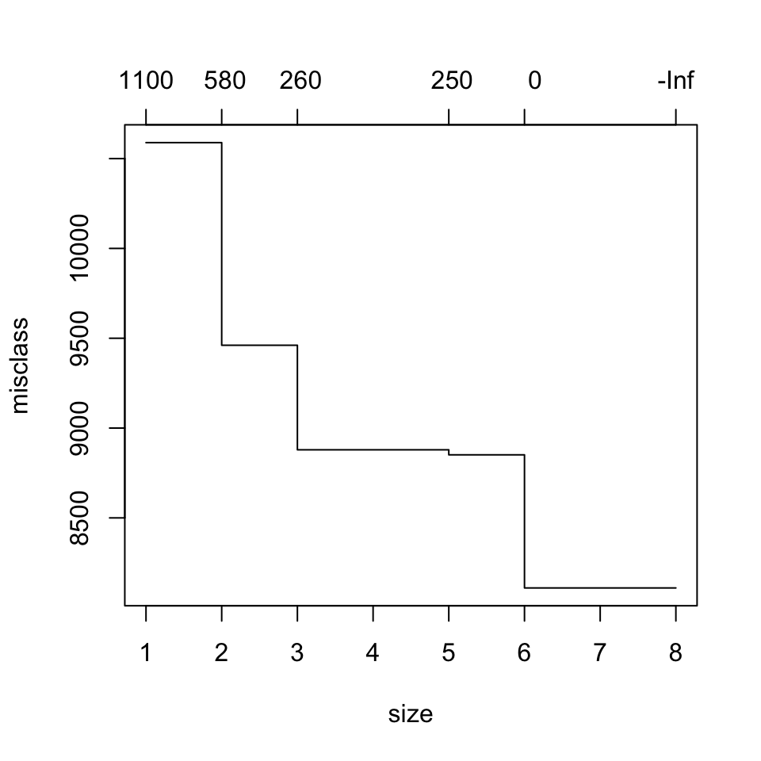

```r
tree.cv.tourism = cv.tree(tree.tourism, FUN= prune.misclass)
plot(tree.cv.tourism)
```

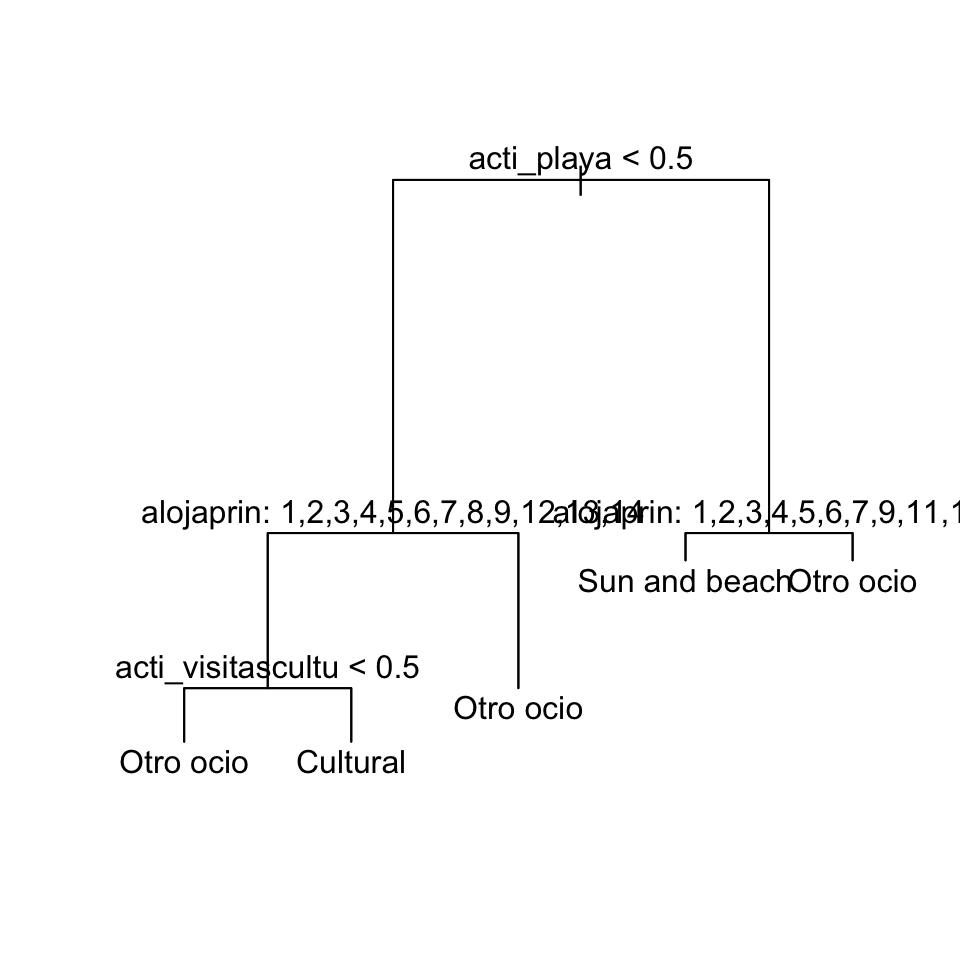

```r
prune.tourism = prune.misclass(tree.tourism, best = 5)
plot(prune.tourism); text(prune.tourism, pretty = 0)
```

```r
tree.pred.cv = predict(prune.tourism, df.test, type="class")
with(df.test, table(tree.pred.cv, motiv))
```

```
##                motiv
## tree.pred.cv    Compras Cultural Gastronomic Nature Otro ocio  Spa Sports
##   Compras             0        0           0      0         0    0      0
##   Cultural            2      379          14     89       240   14     12
##   Gastronomic         0        0           0      0         0    0      0
##   Nature              0        0           0      0         0    0      0
##   Otro ocio          25      152          39    331      2824   43    185
##   Spa                 0        0           0      0         0    0      0
##   Sports              0        0           0      0         0    0      0
##   Sun and beach       5      100          13     54       449    8     14
##                motiv
## tree.pred.cv    Sun and beach
##   Compras                   0
##   Cultural                  8
##   Gastronomic               0
##   Nature                    0
##   Otro ocio               242
##   Spa                       0
##   Sports                    0
##   Sun and beach           918
```

```r
tree.accuracy.cv = mean(tree.pred.cv==df.test$motiv)
```

### 4.3.3 Bosques Aleatorios

El modelo de bosques aleatorios (RF) supone una mejora substancial respecto al modelo de Arboles de Decisión simple. En este método se construyen arboles de decisión de muestras del conjunto de entrenamiento mediante bootstrap considerando una selección aleatoria de m predictores del conjunto total de predictores p.

Por tanto, para aplicar este método es necesario determinar cual es este valor m, es decir, cuantas variables se seleccionarán de forma aleatoria como candidatas en cada división del árbol.

Sin embargo, con el objetivo de encontrar el valor de m que maximiza la “accuracy” de la clasificación, se ha aplicado la Validación Cruzada con 5 “folds”. Para obtener un buen “tuning” de los parámetros del modelo se ha dividido el conjunto de entrenamiento (24,641 observaciones, un 80% del total) en dos subconjuntos, uno que seguirá siendo el de entrenamiento (que contiene el 75% de las observaciones del conjunto original de entrenamiento, 18,484 observaciones o un 60% del total de observaciones de la muestra) y otro que se denomina conjunto de validación (que contiene el 25% restante de las observaciones que se encontraban en el conjunto de entrenamiento original). Por tanto, para el modelo RF se trabajará con 3 subconjuntos de datos: conjunto de entrenamiento (60% de la muestra), conjunto de validación (20%) y conjunto de entrenamiento (20%).

```r
set.seed(111)
# 60% Training, 20% Validation, 20% Test
inTraining <- createDataPartition(df.train$motiv, p=0.75, list=FALSE)
training.set <- df.train[inTraining,]
validation.set <- df.train[-inTraining,]

dataset <- training.set
validation <- validation.set
test <- df.test

# The final model will actually use all data, except test
total <- rbind(dataset, validation)
```

Con el objetivo de limitar el tiempo y los recursos de computación requeridos, se ha limitado el número de alternativas de m a los valores: 3, 7 (valor siguiendo la visión clásica), 11 y 13. En primer lugar se ha estimado el modelo para los datos del conjunto de entrenamiento, aplicando la CV 5-folds, con el objetivo de seleccionar el valor de m que consiga una mayor “accuracy”.

```r
set.seed(111)
# Reduce the grid to save time
fitControl <- trainControl(method = 'cv', number = 5, summaryFunction=defaultSummary)

rfGrid <-  expand.grid(mtry = c(3,7,11,13))

### Random Forest algorithm. ###
fit.rf <- train(motiv~., data=dataset, method = 'rf', trControl=fitControl, tuneGrid=rfGrid, metric='Accuracy', distribution='multinomial')
fit.rf
```

```
## Random Forest
##
## 18484 samples
##    56 predictor
##     8 classes: 'Compras', 'Cultural', 'Gastronomic', 'Nature', 'Otro ocio', 'Spa', 'Sports', 'Sun and beach'
##
## No pre-processing
## Resampling: Cross-Validated (5 fold)
## Summary of sample sizes: 14788, 14786, 14787, 14788, 14787
## Resampling results across tuning parameters:
##
##   mtry  Accuracy   Kappa
##    3    0.6693349  0.3452221
##    7    0.7480525  0.5605254
##   11    0.7542197  0.5808090
##   13    0.7564375  0.5873270
##
## Accuracy was used to select the optimal model using the largest value.
## The final value used for the model was mtry = 13.
```

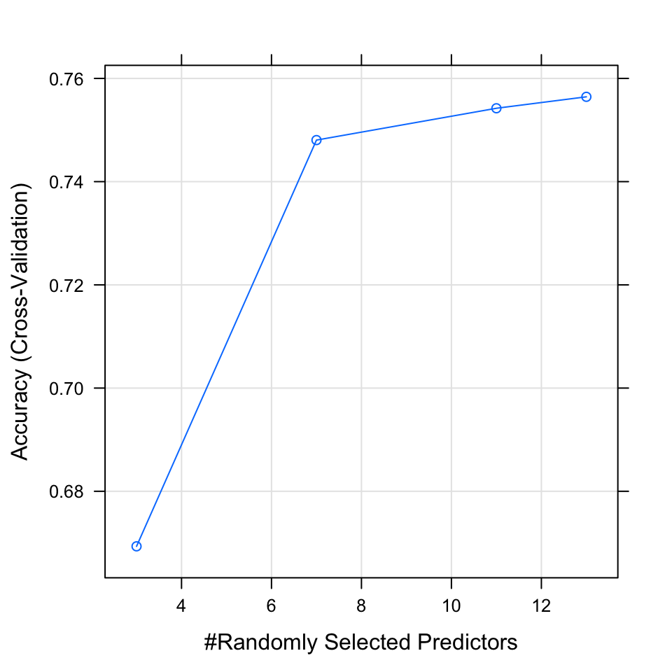

```r
plot(fit.rf)
```

```r
res_rf <- fit.rf$results
acc_rf <- subset(res_rf[2])

# CV con mejor "tune"
max(acc_rf)
```

```
## [1] 0.7564375
```

Tal y como indica la Figura superior, el valor de m que maximiza la tasa de precisión de la CV en el conjunto de entrenamiento es 13. Es decir, considerar 13 predictores aleatorios del conjunto de 56 variables en cada división.

```r
rf.caret.pred <- predict(fit.rf,validation)

rf.val.acc = mean(rf.caret.pred==validation$motiv)
```

```r
table(rf.caret.pred ,validation$motiv)
```

```
##
## rf.caret.pred   Compras Cultural Gastronomic Nature Otro ocio  Spa Sports
##   Compras             8        0           1      0         0    0      0
##   Cultural            1      342          14     28       142    6      5
##   Gastronomic         0        1           9      0         3    0      1
##   Nature              0       20           0    228        47    1     11
##   Otro ocio          22      241          38    195      3008   31     76
##   Spa                 0        1           0      0         4   22      0
##   Sports              0        3           1     11         8    0    105
##   Sun and beach       1       22           3     11       301    5     13
##
## rf.caret.pred   Sun and beach
##   Compras                   0
##   Cultural                 11
##   Gastronomic               0
##   Nature                    1
##   Otro ocio               174
##   Spa                       1
##   Sports                    0
##   Sun and beach           980
```

Finalmente, se estima el modelo anteiror con un mtry = 13 con un CV de 5 “folds” para posteriormente estimar las clases predichas para cada observaciónd del conjunto de prueba.

```r
rfGrid <-  expand.grid(mtry = 13)

fit.rf_total <- train(motiv~., data=total, method = 'rf', trControl=fitControl, tuneGrid=rfGrid, metric='Accuracy', distribution='multinomial')
fit.rf_total
```

```
## Random Forest
##
## 24641 samples
##    56 predictor
##     8 classes: 'Compras', 'Cultural', 'Gastronomic', 'Nature', 'Otro ocio', 'Spa', 'Sports', 'Sun and beach'
##
## No pre-processing
## Resampling: Cross-Validated (5 fold)
## Summary of sample sizes: 19713, 19712, 19715, 19712, 19712
## Resampling results:
##
##   Accuracy   Kappa
##   0.7634022  0.6020356
##
## Tuning parameter 'mtry' was held constant at a value of 13
```

```r
#Evaluate on test
rf.caret.pred_total <- predict(fit.rf_total,test)

rf.accuracy = mean(rf.caret.pred_total==test$motiv)
```

Finalmente el modelo Random Forest obtiene una accuracy igual a 0.77. Siendo esta la más alta de todas las obtenidas hasta el momento.

Finalmente se presenta la matriz de confusión de las clases predichas por el modelo.

```r
table(rf.caret.pred_total ,test$motiv)
```

```
##
## rf.caret.pred_total Compras Cultural Gastronomic Nature Otro ocio  Spa Sports
##       Compras             8        0           0      0         0    0      0
##       Cultural            0      321           9     27       143    4      7
##       Gastronomic         0        1          19      0         2    1      0
##       Nature              0       22           1    240        61    0     16
##       Otro ocio          22      248          32    180      3044   23     68
##       Spa                 0        0           0      1         4   33      0
##       Sports              0        2           0      4         6    0    112
##       Sun and beach       2       37           5     22       253    4      8
##
## rf.caret.pred_total Sun and beach
##       Compras                   0
##       Cultural                 13
##       Gastronomic               0
##       Nature                    2
##       Otro ocio               168
##       Spa                       0
##       Sports                    0
##       Sun and beach           985
```

### 4.3.4 Boosting

Finalmente, se ha implementado un modelo de Boosting, concretamente se ha aplicado la técnica conocida como Boosting Gradient Machine. Esta técnica guarda muchas similitudes con la de Bosques Aleatorios, su principal diferencia es que en este caso los árboles crecen de forma secuencial.

La principal ventaja del boosting reside en que es un modelo que aprende lentamente, evitando así posibles situaciones de “overfitting” (o sobreajuste). Este proceso de aprendizaje lento reside en que se van ajustando pequeños arboles de los residuos del modelo de forma secuencial. De esta manera se mejoran de forma paulatina los parámetros de la función f en aquellas zonas donde falla la predicción (James, Witten, Hastie, & Tibshirani, 2013).

A diferencia del modelo de Bosques Aleatorios dónde tan solo debíamos prefijar un parámetro, en este caso debemos definir tres de ellos: la profundidad del árbol, el número de árboles a construir y el “shrinkage” (que es un parámetro de contracción que realentiza aíun más el proceso de aprendizaje).

Con el fin de obtener los valores para estos parámetros que consigan un mejor “tune” se aplicará el mismo proceso que en el apartado anterior (Bosques Aleatorios) mediante la Validación Cruzada con 3 “folds”. Con el objetivo de limitar los tiempos de ejecución se han limitado los valores que podían tomar cada uno de estos parámetros:

```r
set.seed(111)

#PREPARE A GRID.
gbmGrid <-  expand.grid(interaction.depth = c(3,6,9),
                        n.trees = c(100, 250, 500),
                        shrinkage = c(.001, .01),
                        n.minobsinnode = 10)

fitControl <- trainControl(method = 'cv', number = 3, summaryFunction=defaultSummary)
```

Se aplica cada una de las combinaciones del grid anterior al modelo GBM con los datos del conjunto de entrenamiento

```r
### Gradient boosting machine algorithm. ###
fit.gbm <- train(motiv~., data=df.train, method = 'gbm', trControl=fitControl, tuneGrid=gbmGrid, metric='Accuracy', distribution='multinomial')

fit.gbm
```

En la siguiente figura se presentan los niveles de precisión en la clasificación de las diferentes combinaciones de cada uno de los valores de cada parámetro cuando se aplican a las observaciones del conjunto de entrenamiento mediante un proceso de Validación Cruzada con 3 “folds”.

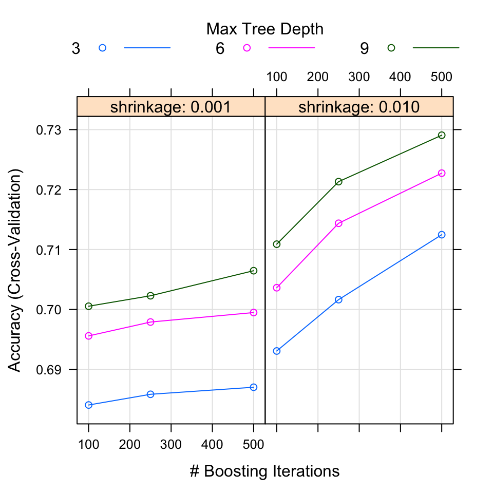

```r
plot(fit.gbm)
```

```r
fit.gbm$bestTune
```

```
##    n.trees interaction.depth shrinkage n.minobsinnode
## 18     500                 9      0.01             10
```

```r
res_gbm <- fit.gbm$results
acc_gbm <- subset(res_gbm[5])

# CV con mejor "tune"
bs.tr.acc = max(acc_gbm)
```

Como podemos comprobar en la figura superior, se obtienen los mejores rendimientos cuando se fija una profundidad máxima de 9 niveles (línea verde) independientemente del número de árboles y el “shrinkage” fijados.

De la misma manera, un “shrinkage” del 0,01 reporta mejores resultados para cada nivel de árboles y para cada profundiad máxima que un “shrinkage” del 0.001.

Finalmente, se observa como, sobretodo en el caso del “shrinkage” fijado al 0.01, a mayor número de árboles se obtiene un mayor nivel de precisión de clasificación.

• Profundidad: 9 niveles • Número de árboles: 500 • Shrinkage: 0,01

Obteniendo una tasa de predicciones correctamente clasificadas del 0.73 (sobre los datos del conjunto de entrenamiento).

Finalmente se ha estimado la clase de cada observación del conjunto de prueba al modelo Boosting previamente entrenado.

En la tabla inferior se presenta la matriz de confunsión:

```r
#Evaluate on test
boost.caret.pred <- predict(fit.gbm,df.test)

table(boost.caret.pred , df.test$motiv)
```

```
##
## boost.caret.pred Compras Cultural Gastronomic Nature Otro ocio  Spa Sports
##    Compras            10        1           0      0         1    0      0
##    Cultural            2      333          10     24       165    4      3
##    Gastronomic         0        4          24      2        16    0      1
##    Nature              0       29           1    179        86    0     20
##    Otro ocio          17      220          23    228      2906   20     70
##    Spa                 0        2           1      4         7   40      0
##    Sports              0        5           0     12        19    0    108
##    Sun and beach       3       37           7     25       313    1      9
##
## boost.caret.pred Sun and beach
##    Compras                   0
##    Cultural                  7
##    Gastronomic               5
##    Nature                    2
##    Otro ocio               234
##    Spa                       3
##    Sports                    3
##    Sun and beach           914
```

```r
bgm.accuracy = mean(boost.caret.pred==df.test$motiv)
```

La accuracy sobre el conjunto de prueba del GBM es de 0.733. Un resultado inferior al obtenido por el Random Forest.

En la tabla y la figura inferiores se presentan el efecto o la influencia de cada variable en el árbol final resultante del proceso de boosting.

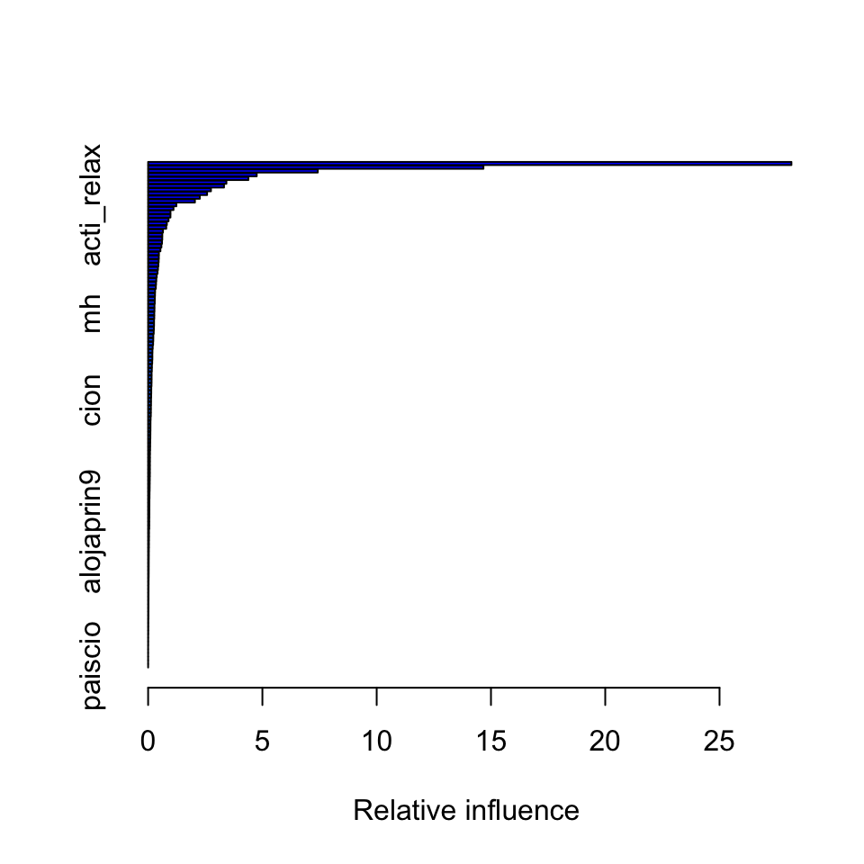

```
##                                                                 var
## acti_playa                                               acti_playa
## alojaprin10                                             alojaprin10
## acti_visitascultu                                 acti_visitascultu
## mes                                                             mes
## gastofi_total                                         gastofi_total
## acti_sender                                             acti_sender
## edad                                                           edad
## acti_depor                                               acti_depor
## acti_areastu                                           acti_areastu
## alojaprin11                                             alojaprin11
## npernoc_corr                                           npernoc_corr
## acti_relax                                               acti_relax
## acti_ciudades                                         acti_ciudades
## acti_gastro                                             acti_gastro
## acti_diver                                               acti_diver
## viaja_amigos                                           viaja_amigos
## acti_familia                                           acti_familia
## acti_especdepor                                     acti_especdepor
## provdestAsturias                                   provdestAsturias
## alojaprin5                                               alojaprin5
## acti_otrosdeportes                               acti_otrosdeportes
## acti_especultu                                       acti_especultu
## ingr_hog                                                   ingr_hog
## acti_rurales                                           acti_rurales
## tamamu                                                       tamamu
## nivelest                                                   nivelest
## tipoviaj                                                   tipoviaj
## provdestHuesca                                       provdestHuesca
## ecivil                                                       ecivil
## miemv                                                         miemv
## ccaa_residenciaCataluna                     ccaa_residenciaCataluna
## tiphogar                                                   tiphogar
## vivsec                                                       vivsec
## miemv_15mas                                             miemv_15mas
## acti_caza                                                 acti_caza
## alojaprin14                                             alojaprin14
## acti_compras                                           acti_compras
## acti_tematicos                                       acti_tematicos
## provdestMadrid                                       provdestMadrid
```

[output cut: 217 more lines]

```
## provdestSoria                      0.012799869
## provdestBadajoz                    0.012457950
## acti_golf                          0.007591021
## alojaprin4                         0.007361232
## provdestGuadalajara                0.006458868
## provdestBurgos                     0.005958053
## acti_juegos                        0.003359627
## provdestOurense                    0.002728990
## provdestPalencia                   0.002724542
## provdestCeuta                      0.000000000
## provdestMelilla                    0.000000000
## alojaprin8                         0.000000000
## alojaprin12                        0.000000000
## alojaprin13                        0.000000000
## paiscio                            0.000000000
```

```r
summary(fit.gbm, n.trees=500)
```

La práctica de actividades de playa resulta ser el predictor más influyente en el modelo, este resultado es el mismo que en el caso del Árbol de Decisión simple, donde las actividades de playa también se revelaban como el predictor mas importante a la hora de clasificar la motivación de los turistas a la hora de viajar.

En segundo lugar, encontramos el alojamiento principal en destino, en concreto si el turista desea hospedarse en un alojamiento de la clase 10, que se corresponde a la categoría de vivienda en propiedad. Una vez más se trata de un predictor con gran peso en el modelo de Árbol de Decisión.

# 5 Conclusiones y limitaciones del estudio

El objetivo de este trabajo era el de aplicar diferentes técnicas de Aprendizaje Automático/Estadístico al problema de la clasificación de los turistas dependiendo de sus motivaciones para viajar.

Como ya se ha explicado esta información puede ser de gran valor para las empresas del sector, en especial aquellas que venden productos turísticos on-line. Conociendo de antemano que motivaciones tiene el turista para viajar (p.e, es un turista de sol y playa, o uno cultural, …) se pueden optimizar las campañas de marketing consiguiendo una mayor precisión en la identificación del target. Con el objetivo de que los resultados obtenidos en este proyecto sean extrapolables a situaciones reales, las variables incluidas en el modelo podrían ser recolectadas por cualquier empresa interesada en aplicar los modelos.

Llegados a este punto se han aplicado un total de 6 técnicas de diferentes, con sus múltiples especificaciones. En todas ellas se ha aplicado la Validación Cruzada con el objetivo de evitar problemas relacionados con el sobreajuste de los modelos, así como de conseguir un mejor “tuning” de los parámetros de cada uno de los modelos.

```r
baseline = 0.5703

DT = data.table( Baseline = round(baseline, 4)*100,
                 KNN = round(knn.accuracy.k1, 4)*100,
                 LDA = round(lda.accuracy, 4)*100,
                 Arbol = round(tree.accuracy, 4)*100,
                 Arbol.Prune  =  round(tree.accuracy.cv, 4)*100,
                 Random.Forest =  round(rf.accuracy, 4)*100,
                 Boosting = round(bgm.accuracy, 4)*100
)
DT
```

```
##    Baseline  KNN LDA Arbol Arbol.Prune Random.Forest Boosting
## 1:    57.03 61.6  67 67.69        66.9         77.31    73.28
```

Si nos referimos al modelo de clasificación mas simple como “baseline” o punto de partida (clasificar todas las nuevas observaciones por la clase con mayor peso de la muestra), observamos como todos los modelos aplicados consiguen mejorar el proceso de clasificación de turistas.

El modelo de KNN con 1 vecino resulta ser el consigue un peor rendimiento. A medida que se incrementa la complejidad de los modelos aplicados, mayor es el nivel de precisión que se consigue. Mientras que los modelos de Análisis Discriminante Lineal y Árbol de Decisión (con y sin poda) no alcanzan el 70% de corrección en la clasificación, los de la regresión Logístia así como el de Bosque Aleatorio y Boosting si logran superar esta barrera.

El modelo que consigue clasificar un mayor número de nuevas observaciones de forma correcta en el de Bosque Aleatorio, con una tasa de acierto del 0.7730519, que representa una mejor de más de 20 puntos porcentuales con respecto al punto de partida.

En cuanto al rol de los predictores, cabe destacar la importancia de las actividades que quiere realizar el turista en sus vacaciones (sobretodo las actividades de playa) y el tipo de alojamiento que prefiere. Estos dos resultan ser los predictores dominantes en todos los modelos relacionados con los Árboles de Decisión (incluyendo el modelo de Boosting).

Finalmente, es importante señalar las limitaciones de este estudio. La mayoría de ellas residen en la capacidad de computación de la que se ha dispuesto. Concretamente, ha resultado imposible tener en cuenta todas las combinaciones de parámetros posibles en los modelos de Bosques Aleatorios y de Boosting.

En el modelo de Bosques Aleatorios, se ha observado un crecimiento paulatino del nivel de “accuracy” a medida que se aumentaba el número de predictores seleccionados aleatoriamente que se consideraban, el parámetro m. Sin embargo, debido a estas limitaciones computacionales se ha tenido que fijar el máximo en 13 predictores.

En el caso del modelo aplicando Boosting, las limitaciones son mayores ya que se han tenido que limitar el número de valores que podían tomar un total de 3 parámetros. Los resultados parecen indicar que incrementos en el número de árboles seguirían incrementando la precisión del modelo, sin embargo, las limitaciones de computación (y de tiempo) han imposibilitado extender el análisis. Tampoco se ha podido aplicar un modelo de Extreme Gradient Boosting debido a las mismas limitaciones.

En cualquier caso, estas limitaciones no invalidan que ambos modelos son los que obtienen un mejor rendimiento en términos de clasificaciones correctas sobre el conjunto de prueba. Finalmente, cabe señalar que otros modelos como las Redes Neuronales o las “Support Vector Machines”, a pesar de obtener potenciales mejores niveles de clasificación correcta, no han sido incluidos en el análisis debido a que no formaban parte del conjunto de técnicas evaluables.